#### Modelos de Regressão para Dados de Contagem com o R

##### [`github.com/leg-ufpr/MRDCr`](https://github.com/leg-ufpr/MRDCr)

# Análise de Contagens com o Modelo COM-Poisson

Walmes M. Zeviani, Eduardo E. Ribeiro Jr & Cesar A. Taconeli

```r
library(MRDCr)
```

# Funções para ajuste dos modelos

## Log-verossimilhança

Implentando a função de log-verossimilhança do modelo COM-Poisson, definida como:

$$\sum_i^n y_i \log(\lambda_i) - \nu \sum_i^n \log(y_i!) -
\sum_i^n \log(Z(\lambda_i, \nu))$$

em que $Z(\lambda_i, \nu) = \sum_{j=0}^\infty \lambda_i^j (j!)^{-\nu}$ e $\lambda_i = \exp(X_i\beta)$

**Detalhes computacionais**

- Reparametrização do parâmetro $\nu$ para $\phi = \log(\nu)$. Assim o espaço paramétrico do modelo são os reais $\Re^n$.
- Truncamento da série infinita $Z(\lambda_i)$. `sumto` é tomado como argumento da função.
- Para o cálculo de $Z(\lambda_i)$ faz-se, minimizando problemas de *overflow*
  $$\sum_{j=0}^\infty \lambda_i^j (j!)^{-\nu} =
  \sum_{j=0}^\infty \exp \left ( \log \left(
  \lambda_i^j (j!)^{-\nu} \right ) \right ) =
  \sum_{j=0}^\infty \exp(i \log(\lambda_i) - \nu \log(i!))$$

```r
llcmp
```

```
## function (params, y, X, sumto = ceiling(max(y)^1.2))
## {
##     betas <- params[-1]
##     phi <- params[1]
##     nu <- exp(phi)
##     Xb <- X %*% betas
##     i <- 0:sumto
##     zs <- sapply(Xb, function(loglambda) sum(exp(i * loglambda -
##         nu * lfactorial(i))))
##     Z <- sum(log(zs))
##     ll <- sum(y * Xb - nu * lfactorial(y)) - Z
##     return(-ll)
## }
## <environment: namespace:MRDCr>
```

## Ajuste geral

*Framework* implementado em R que utiliza a forma de escrita de preditores no estilo de fórmulas, similar as funções `lm`, `glm`.

```r
cmp
```

```
## function (formula, data, start = NULL, sumto = NULL, ...)
## {
##     frame <- model.frame(formula, data)
##     terms <- attr(frame, "terms")
##     y <- model.response(frame)
##     X <- model.matrix(terms, frame)
##     if (!is.null(model.offset(frame))) {
##         stop("Este modelo ainda nao suporta offset")
##     }
##     if (is.null(sumto))
##         sumto <- ceiling(max(y)^1.2)
##     if (is.null(start)) {
##         m0 <- glm.fit(x = X, y = y, family = poisson())
##         start <- c(phi = 0, m0$coefficients)
##     }
##     bbmle::parnames(llcmp) <- names(start)
##     model <- bbmle::mle2(llcmp, start = start, data = list(y = y,
##         X = X, sumto = sumto), vecpar = TRUE, ...)
##     return(model)
## }
## <environment: namespace:MRDCr>
```

Um exemplo de como são construídas as matrizes, definidos os chutes iniciais e ajustados os modelos na função:

```r
set.seed(2016)
x <- rep(1:3, 3)
y <- rpois(9, lambda = x)
(da <- data.frame(x, y))
```

```
##   x y
## 1 1 0
## 2 2 1
## 3 3 5
## 4 1 0
## 5 2 2
## 6 3 1
## 7 1 1
## 8 2 4
## 9 3 0
```

```r
## Definindo o prditor do modelo
formula <- y ~ x + I(x^2)

##-------------------------------------------
## O framework

## Constrói as matrizes para ajuste do modelo
frame <- model.frame(formula, data = da)
(X <- model.matrix(formula, data = da))
```

```
##   (Intercept) x I(x^2)
## 1           1 1      1
## 2           1 2      4
## 3           1 3      9
## 4           1 1      1
## 5           1 2      4
## 6           1 3      9
## 7           1 1      1
## 8           1 2      4
## 9           1 3      9
## attr(,"assign")
## [1] 0 1 2
```

```r
(y <- model.response(frame))
```

```
## 1 2 3 4 5 6 7 8 9
## 0 1 5 0 2 1 1 4 0
```

```r
## Utiliza como valores iniciais as estimativas dos parametros de um
## modelo GLM-Poisson
m0 <- glm.fit(x = X, y = y, family = poisson())
(start <- c(phi = 0, m0$coefficients))
```

```
##         phi (Intercept)           x      I(x^2)
##    0.000000   -5.144583    5.096001   -1.050030
```

```r
## Otimiza a função de log-verossimilhança via bbmle
library(bbmle)
parnames(llcmp) <- names(start)
mle2(llcmp, start = start,
     data = list(y = y, X = X, sumto = 50),
     vecpar = TRUE)
```

```
##
## Call:
## mle2(minuslogl = llcmp, start = start, data = list(y = y, X = X,
##     sumto = 50), vecpar = TRUE)
##
## Coefficients:
##         phi (Intercept)           x      I(x^2)
##  -0.5769066  -4.4398609   4.0697971  -0.8354618
##
## Log-likelihood: -13.44
```

# Capulhos de algodão sob exposição à mosca-branca

```r
data(capmosca)
str(capmosca)
```

```
## 'data.frame':    60 obs. of  8 variables:
##  $ dexp   : int  0 0 0 0 0 0 0 0 0 0 ...
##  $ vaso   : Factor w/ 5 levels "1","2","3","4",..: 1 1 2 2 3 3 4 4 5 5 ...
##  $ planta : Factor w/ 2 levels "1","2": 1 2 1 2 1 2 1 2 1 2 ...
##  $ alt    : num  70.5 67.5 72 70 64 64.5 67.5 61 70 70 ...
##  $ pesocap: num  25.2 NA 28.5 NA 31.8 ...
##  $ nerep  : int  4 4 3 5 5 5 5 5 4 5 ...
##  $ ncap   : int  4 4 2 5 5 5 5 5 4 5 ...
##  $ nnos   : int  13 14 14 15 15 11 14 11 14 15 ...
```

```r
## help(capmosca)
```

Experimento conduzido sob delineamento inteiramente casualizado na Universidade Federal da Grande Dourados, cujo objetivo foi avaliar os impactos da exposição de plantas de algodão à alta infestação da praga mosca-branca. No experimento avaliou-se duas plantas por vaso, nesta análise tomaremos como unidade amostral o vaso e o interesse será somente na variável número de capulhos produzidos.

```r
capmosca <- aggregate(ncap ~ vaso + dexp, data = capmosca, FUN = sum)
str(capmosca)
```

```
## 'data.frame':    30 obs. of  3 variables:
##  $ vaso: Factor w/ 5 levels "1","2","3","4",..: 1 2 3 4 5 1 2 3 4 5 ...
##  $ dexp: int  0 0 0 0 0 1 1 1 1 1 ...
##  $ ncap: int  8 7 10 10 9 5 7 8 8 11 ...
```

Assim as variáveis consideradas são definidas como:

- `dexp`: Dias de exposição à alta infestação de mosca-branca;
- `ncap`: Número de capulhos de algodão produzidos ao final do experimento.

## Análise Exploratória

```r
## Experimento balanceado
xtabs(~dexp, data = capmosca)
```

```
## dexp
## 0 1 2 3 4 5
## 5 5 5 5 5 5
```

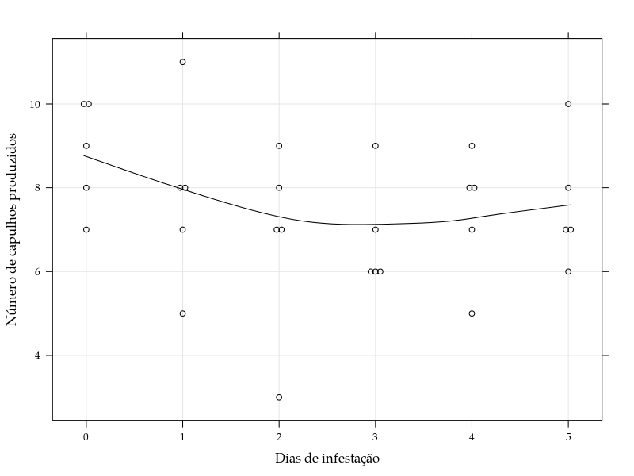

```r
library(lattice)
library(latticeExtra)

(xy <- xyplot(ncap ~ dexp,
              data = capmosca,
              xlab = "Dias de infestação",
              ylab = "Número de capulhos produzidos",
              type = c("p", "g", "smooth"),
              panel = panel.beeswarm,
              r = 0.05))
```

```r
## Avaliando preliminarmente suposição de equidispersão
(mv <- aggregate(ncap ~ dexp, data = capmosca,
                 FUN = function(x) c(mean = mean(x), var = var(x))))
```

```
##   dexp ncap.mean ncap.var
## 1    0       8.8      1.7
## 2    1       7.8      4.7
## 3    2       6.8      5.2
## 4    3       6.8      1.7
## 5    4       7.4      2.3
## 6    5       7.6      2.3
```

## Ajuste dos modelos

```r
## Preditores considerados
f1 <- ncap ~ 1
f2 <- ncap ~ dexp
f3 <- ncap ~ dexp + I(dexp^2)

## Ajustando os modelos Poisson
m1P <- glm(f1, data = capmosca, family = poisson)
m2P <- glm(f2, data = capmosca, family = poisson)
m3P <- glm(f3, data = capmosca, family = poisson)

## Ajustando os modelos COM-Poisson
m1C <- cmp(f1, data = capmosca)
m2C <- cmp(f2, data = capmosca)
m3C <- cmp(f3, data = capmosca)
```

## Comparação dos ajustes

```r
## Verossimilhancas dos modelos ajustados
cbind("Poisson" = sapply(list(m1P, m2P, m3P), logLik),
      "COM-Poisson" = sapply(list(m1C, m2C, m3C), logLik))
```

```
##        Poisson COM-Poisson
## [1,] -63.76981   -58.77209
## [2,] -63.52399   -58.13540
## [3,] -62.93611   -56.49274
```

```r
## Teste de razão de verossimilhanças
anova(m1P, m2P, m3P, test = "Chisq")
```

```
## Analysis of Deviance Table
##
## Model 1: ncap ~ 1
## Model 2: ncap ~ dexp
## Model 3: ncap ~ dexp + I(dexp^2)
##   Resid. Df Resid. Dev Df Deviance Pr(>Chi)
## 1        29     11.993
## 2        28     11.501  1  0.49164   0.4832
## 3        27     10.325  1  1.17575   0.2782
```

```r
anova(m1C, m2C, m3C)
```

```
## Likelihood Ratio Tests
## Model 1: m1C, [llcmp]: phi+(Intercept)
## Model 2: m2C, [llcmp]: phi+(Intercept)+dexp
## Model 3: m3C, [llcmp]: phi+(Intercept)+dexp+I(dexp^2)
##   Tot Df Deviance  Chisq Df Pr(>Chisq)
## 1      2   117.54
## 2      3   116.27 1.2734  1     0.2591
## 3      4   112.98 3.2853  1     0.0699 .
## ---
## Signif. codes:  0 '***' 0.001 '**' 0.01 '*' 0.05 '.' 0.1 ' ' 1
```

```r
## Estimativas dos parâmetros
summary(m3P)
```

```
##
## Call:
## glm(formula = f3, family = poisson, data = capmosca)
##
## Deviance Residuals:
##      Min        1Q    Median        3Q       Max
## -1.72211  -0.32208   0.01768   0.34877   1.13445
##
## Coefficients:
##             Estimate Std. Error z value Pr(>|z|)
## (Intercept)  2.17571    0.13842  15.718   <2e-16 ***
## dexp        -0.16923    0.13586  -1.246    0.213
## I(dexp^2)    0.02870    0.02638   1.088    0.277
## ---
## Signif. codes:  0 '***' 0.001 '**' 0.01 '*' 0.05 '.' 0.1 ' ' 1
##
## (Dispersion parameter for poisson family taken to be 1)
##
##     Null deviance: 11.993  on 29  degrees of freedom
## Residual deviance: 10.325  on 27  degrees of freedom
## AIC: 131.87
##
## Number of Fisher Scoring iterations: 4
```

```r
summary(m3C)
```

```
## Maximum likelihood estimation
##
## Call:
## bbmle::mle2(minuslogl = llcmp, start = start, data = list(y = y,
##     X = X, sumto = sumto), vecpar = TRUE)
##
## Coefficients:
##              Estimate Std. Error z value     Pr(z)
## phi          1.125801   0.261944  4.2979 1.724e-05 ***
## (Intercept)  6.824074   1.817549  3.7545 0.0001737 ***
## dexp        -0.499139   0.266247 -1.8747 0.0608317 .
## I(dexp^2)    0.084627   0.050231  1.6848 0.0920341 .
## ---
## Signif. codes:  0 '***' 0.001 '**' 0.01 '*' 0.05 '.' 0.1 ' ' 1
##
## -2 log L: 112.9855
```

## Avaliando modelo proposto

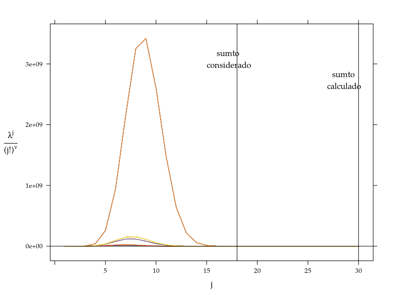

```r
## Um dos problemas computacionais do modelo COM-Poisson é a obtenção da
## constante de normalização Z. Assim uma visualização pós ajuste para
## verificar se o ajuste proporcionou uma densidade válida se faz
## necessária
convergencez(m3C)
```

```r
## Reajustando o modelo
logLik(m3C <- cmp(f3, data = capmosca, sumto = 30))
```

```
## 'log Lik.' -56.49274 (df=4)
```

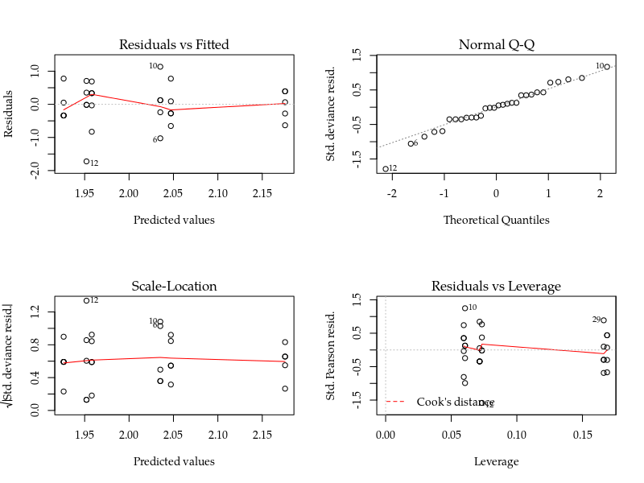

```r
## Dado que o modelo COM-Poisson leva as mesmas estimativas pontuais que
## o modelo Poisson a análise de diagnóstico padrão pode ser utilizada
par(mfrow = c(2, 2))
plot(m3P)
```

```r
##-------------------------------------------
## Testando a nulidade do parâmetro phi

## Usando o ajuste Poisson
trv <- 2 * (logLik(m3C) - logLik(m3P))
attributes(trv) <- NULL
round(c(trv, pchisq(trv, 1, lower = FALSE)), digits = 5)
```

```
## [1] 12.88675  0.00033
```

```r
## Reajustando o COM-Poisson para phi = 0 (ou equivalente nu = 1)
m3Cfixed <- cmp(f3, data = capmosca, fixed = list("phi" = 0))
anova(m3C, m3Cfixed)
```

```
## Likelihood Ratio Tests
## Model 1: m3C, [llcmp]: phi+(Intercept)+dexp+I(dexp^2)
## Model 2: m3Cfixed, [llcmp]: (Intercept)+dexp+I(dexp^2)
##   Tot Df Deviance  Chisq Df Pr(>Chisq)
## 1      4   112.98
## 2      3   125.87 12.887  1  0.0003309 ***
## ---
## Signif. codes:  0 '***' 0.001 '**' 0.01 '*' 0.05 '.' 0.1 ' ' 1
```

```r
## Via perfil de log-verossimilhança
perf <- profile(m3C, which = 1)
confint(perf)
```

```
##     2.5 %    97.5 %
## 0.5622126 1.5977357
```

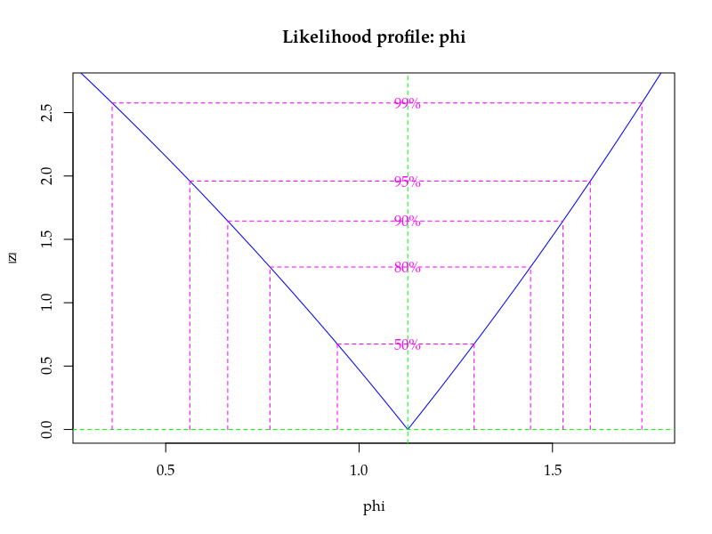

```r
plot(perf)
```

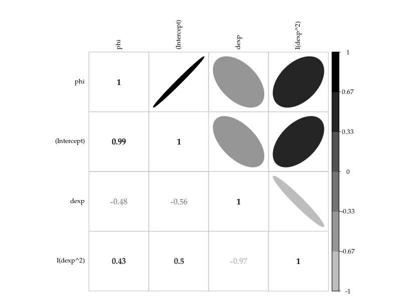

```r
##-------------------------------------------
## Verificando a matriz ve variâncias e covariâncias
Vcov <- vcov(m3C)
Corr <- cov2cor(Vcov)

library(corrplot)
corrplot.mixed(Corr, lower = "number", upper = "ellipse",
               diag = "l", tl.pos = "lt", tl.col = "black",
               tl.cex = 0.8, col = brewer.pal(9, "Greys")[-(1:3)])
```

## Predição

```r
## Predição pontual/intervalar
pred <- with(capmosca,
             expand.grid(
                 dexp = seq(min(dexp), max(dexp), l = 50)
             ))
qn <- qnorm(0.975) * c(fit = 0, lwr = -1, upr = 1)

##-------------------------------------------
## Considerando a Poisson
aux <- predict(m3P, newdata = pred, se.fit = TRUE)
aux <- with(aux, exp(fit + outer(se.fit, qn, FUN = "*")))
aux <- data.frame(modelo = "Poisson", aux)
predP <- cbind(pred, aux)

##-------------------------------------------
## Considerando a COM-Poisson
f3; f3[-2]
```

```
## ncap ~ dexp + I(dexp^2)
```

```
## ~dexp + I(dexp^2)
```

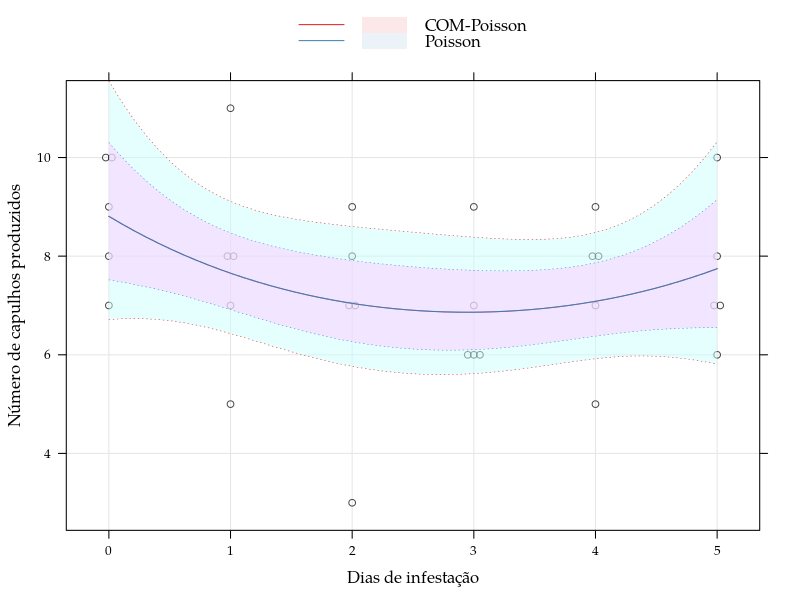

```r
X <- model.matrix(f3[-2], data = pred)

aux <- predict(m3C, newdata = X, type = "response",
               interval = "confidence")
aux <- data.frame(modelo = "COM-Poisson", aux)
predC <- cbind(pred, aux)

##-------------------------------------------
## Visualizando os valores preditos intervalares pelos dois modelos
da <- rbind(predP, predC)

## Legenda
cols <- trellis.par.get("superpose.line")$col[1:2]
key <- list(
    lines = list(lty = 1, col = cols),
    rect = list(col = cols, alpha = 0.1, lty = 3, border = NA),
    text = list(c("COM-Poisson", "Poisson")))

## Gráfico dos valores preditos e IC de 95% para média
update(xy, type = c("p", "g"), key = key, alpha = 0.7) +
    as.layer(xyplot(fit ~ dexp,
                    groups = modelo,
                    data = da,
                    type = "l",
                    ly = da$lwr,
                    uy = da$upr,
                    cty = "bands",
                    alpha = 0.5,
                    prepanel = prepanel.cbH,
                    panel.groups = panel.cbH,
                    panel = panel.superpose))
```

# Produção de soja sob efeito de umidade e adubação potássica

```r
data(soja)
str(soja)
```

```
## 'data.frame':    75 obs. of  5 variables:
##  $ K   : int  0 30 60 120 180 0 30 60 120 180 ...
##  $ umid: Factor w/ 3 levels "37,5","50","62,5": 1 1 1 1 1 2 2 2 2 2 ...
##  $ bloc: Factor w/ 5 levels "I","II","III",..: 1 1 1 1 1 1 1 1 1 1 ...
##  $ ngra: int  136 159 156 171 190 140 193 200 208 237 ...
##  $ nvag: int  56 62 66 68 82 63 86 94 86 97 ...
```

```r
## help(soja)
```

Dados resultantes de um experimento fatorial 5 $\times$ 3 conduzido em casa de vegetação, onde experimentou-se diferentes níveis de umidade do solo e níveis de adubação com potássio em parcelas que continham 2 plantas. O interesse deste estudo foi avaliar o impacto desses fatores na produção de soja, mensurada pelos componentes número grãos e número de vagegns viáveis. Para controle de variação local, as parcelas foram arranjadas em blocos. Como temos somente três níveis de umidade aplicados trabalharemos esta variável como categórica. Outra observação é quanto a observação 74, que foi considerada como outlier pelo pesquisador responsável e portanto retirada da análise.

```r
## Observação 74 foi diagnosticada como outlier
soja <- soja[-74, ]
soja <- transform(soja, K = factor(K))
```

Abaixo definimos as variáveis que são utilizadas na modelagem.

- `bloc`: Fator categórico para controle local no experimento. Foram controladas as variações de ambiente da casa de vegetação, como exposição ao sol, e mão de obra ao longo do experimento, como irrigação e capina dos vasos e controle de doenças.
- `umid`: Fator de níveis categóricos. Faixas de umidade do solo. Procurou-se por meio de pesagens diárias dos vasos, manter a umidade do solo nas faixas de 35 a 40; 47,5 a 52,5; e 60 a 65 do volume total de poros.
- `K`: fator de níveis métricos. Dose de potássio aplicado ao solo na forma de adubação, em mg dm$^{-3}$.

## Análise Exploratória

```r
## Experimento (des)balanceado
xtabs(~K + umid, data = soja)
```

```
##      umid
## K     37,5 50 62,5
##   0      5  5    5
##   30     5  5    5
##   60     5  5    5
##   120    5  5    4
##   180    5  5    5
```

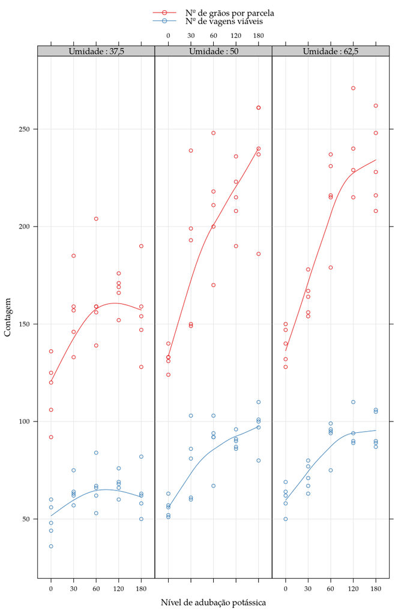

```r
key <- list(
    type = "b", divide = 1,
    ## points = list(pch = 1, col = cols),
    lines = list(pch = 1, lty = 1, col = cols),
    text = list(c("Nº de grãos por parcela", "Nº de vagens viáveis")))

xyplot(ngra + nvag ~ K | umid,
       data = soja,
       xlab = "Nível de adubação potássica",
       ylab = "Contagem",
       type = c("p", "g", "smooth"),
       key = key,
       layout = c(NA, 1),
       strip = strip.custom(
           strip.names = TRUE, var.name = "Umidade"))
```

```r
## Avaliando preliminarmente suposição de equidispersão
(mv <- aggregate(cbind(ngra, nvag, ng2v = ngra/nvag) ~ K + umid,
                 data = soja, FUN = function(x)
                     c(mean = mean(x), var = var(x))))
```

```
##      K umid ngra.mean  ngra.var nvag.mean  nvag.var   ng2v.mean
## 1    0 37,5  115.8000  293.2000  48.80000  91.20000 2.395310245
## 2   30 37,5  156.0000  370.0000  64.20000  43.70000 2.427565924
## 3   60 37,5  163.4000  584.3000  66.40000 127.30000 2.470499952
## 4  120 37,5  166.8000   81.7000  67.80000  33.20000 2.466046370
## 5  180 37,5  155.6000  508.3000  63.00000 139.00000 2.484103301
## 6    0   50  132.2000   32.7000  55.80000  22.70000 2.377585272
## 7   30   50  186.0000 1423.0000  78.20000 327.70000 2.392742849
## 8   60   50  209.4000  801.8000  89.60000 180.30000 2.347156695
## 9  120   50  214.4000  294.3000  90.00000  15.50000 2.380056874
## 10 180   50  237.0000  940.5000  97.60000 120.30000 2.425452773
## 11   0 62,5  139.4000   88.8000  60.60000  50.80000 2.313648571
## 12  30 62,5  163.8000   92.2000  71.60000  48.80000 2.295677653
## 13  60 62,5  215.6000  508.8000  91.80000  91.70000 2.349956047
## 14 120 62,5  238.7500  566.9167  95.75000  94.91667 2.494250659
```

[output cut: 17 more lines]

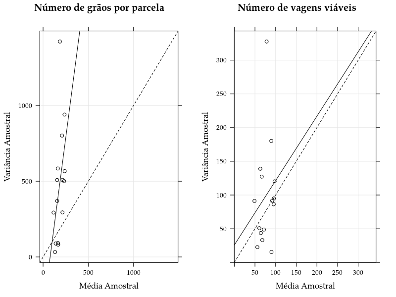

```r
##-------------------------------------------
## Para o número de grãos
xlim <- ylim <- extendrange(c(mv$ngra), f = 0.05)
mvp1 <- xyplot(ngra[, "var"] ~ ngra[, "mean"],
               data = mv,
               xlim = xlim, ylim = ylim,
               ylab = "Variância Amostral",
               xlab = "Média Amostral",
               main = "Número de grãos por parcela",
               panel = function(x, y) {
                   panel.xyplot(x, y, type = c("p", "r"), grid = TRUE)
                   panel.abline(a = 0, b = 1, lty = 2)
               })

##-------------------------------------------
## Para o número de vagens
xlim <- ylim <- extendrange(c(mv$nvag), f = 0.05)
mvp2 <- xyplot(nvag[, "var"] ~ nvag[, "mean"],
               data = mv,
               xlim = xlim, ylim = ylim,
               ylab = "Variância Amostral",
               xlab = "Média Amostral",
               main = "Número de vagens viáveis",
               panel = function(x, y) {
                   panel.xyplot(x, y, type = c("p", "r"), grid = TRUE)
                   panel.abline(a = 0, b = 1, lty = 2)
               })

print(mvp1, split = c(1, 1, 2, 1), more = TRUE)
print(mvp2, split = c(2, 1, 2, 1), more = FALSE)
```

## Ajuste dos modelos

```r
##-------------------------------------------
## Para o número de vagens viáveis por parcela

## Preditores considerados
f1.nv <- nvag ~ bloc + umid + K
f2.nv <- nvag ~ bloc + umid * K

## Ajustando os modelos Poisson
m1P.nv <- glm(f1.nv, data = soja, family = poisson)
m2P.nv <- glm(f2.nv, data = soja, family = poisson)

## Ajustando os modelos COM-Poisson
m1C.nv <- cmp(f1.nv, data = soja, sumto = 300)
m2C.nv <- cmp(f2.nv, data = soja, sumto = 300)

##-------------------------------------------
## Para o número grão produzidos por parcela

## Preditores considerados
f1.ng <- ngra ~ bloc + umid + K
f2.ng <- ngra ~ bloc + umid * K

## Ajustando os modelos Poisson
m1P.ng <- glm(f1.ng, data = soja, family = poisson)
m2P.ng <- glm(f2.ng, data = soja, family = poisson)

## Ajustando os modelos COM-Poisson
m1C.ng <- cmp(f1.ng, data = soja, sumto = 700)
m2C.ng <- cmp(f2.ng, data = soja, sumto = 700)
```

## Comparação dos ajustes

```r
##-------------------------------------------
## Verossimilhancas dos modelos ajustados
cbind("Poisson" = sapply(
          list("nvagem adtv" = m1P.nv, "nvagem mult" = m2P.nv,
               "ngraos adtv" = m1P.ng, "ngraos mult" = m2P.ng),
          logLik),
      "COM-Poisson" = sapply(
          list(m1C.nv, m2C.nv, m1C.ng, m2C.ng),
          logLik))
```

```
##               Poisson COM-Poisson
## nvagem adtv -266.6918   -266.6018
## nvagem mult -259.6165   -259.3267
## ngraos adtv -343.1633   -326.6072
## ngraos mult -321.6692   -315.6448
```

```r
##-------------------------------------------
## Teste de razão de verossimilhanças

## Dos modelos para o número de vagens viáveis
anova(m1P.nv, m2P.nv, test = "Chisq")
```

```
## Analysis of Deviance Table
##
## Model 1: nvag ~ bloc + umid + K
## Model 2: nvag ~ bloc + umid * K
##   Resid. Df Resid. Dev Df Deviance Pr(>Chi)
## 1        63     79.429
## 2        55     65.278  8    14.15  0.07793 .
## ---
## Signif. codes:  0 '***' 0.001 '**' 0.01 '*' 0.05 '.' 0.1 ' ' 1
```

```r
anova(m1C.nv, m2C.nv)
```

```
## Likelihood Ratio Tests
## Model 1: m1C.nv, [llcmp]: phi+(Intercept)+blocII+blocIII+
##           blocIV+blocV+umid50+umid62,5+K30+K60+K120+K180
## Model 2: m2C.nv, [llcmp]: phi+(Intercept)+blocII+blocIII+
##           blocIV+blocV+umid50+umid62,5+K30+K60+K120+K180+
##           umid50:K30+umid62,5:K30+umid50:K60+umid62,5:K60+
##           umid50:K120+umid62,5:K120+umid50:K180+umid62,5:K180
##   Tot Df Deviance Chisq Df Pr(>Chisq)
## 1     12   533.20
## 2     20   518.65 14.55  8     0.0685 .
## ---
## Signif. codes:  0 '***' 0.001 '**' 0.01 '*' 0.05 '.' 0.1 ' ' 1
```

```r
## Dos modelos para o número de grão por parcela
anova(m1P.ng, m2P.ng, test = "Chisq")
```

```
## Analysis of Deviance Table
##
## Model 1: ngra ~ bloc + umid + K
## Model 2: ngra ~ bloc + umid * K
##   Resid. Df Resid. Dev Df Deviance Pr(>Chi)
## 1        63     167.71
## 2        55     124.72  8   42.988 8.83e-07 ***
## ---
## Signif. codes:  0 '***' 0.001 '**' 0.01 '*' 0.05 '.' 0.1 ' ' 1
```

```r
anova(m1C.ng, m2C.ng)
```

```
## Likelihood Ratio Tests
## Model 1: m1C.ng, [llcmp]: phi+(Intercept)+blocII+blocIII+
##           blocIV+blocV+umid50+umid62,5+K30+K60+K120+K180
## Model 2: m2C.ng, [llcmp]: phi+(Intercept)+blocII+blocIII+
##           blocIV+blocV+umid50+umid62,5+K30+K60+K120+K180+
##           umid50:K30+umid62,5:K30+umid50:K60+umid62,5:K60+
##           umid50:K120+umid62,5:K120+umid50:K180+umid62,5:K180
##   Tot Df Deviance  Chisq Df Pr(>Chisq)
## 1     12   653.21
## 2     20   631.29 21.925  8   0.005057 **
## ---
## Signif. codes:  0 '***' 0.001 '**' 0.01 '*' 0.05 '.' 0.1 ' ' 1
```

```r
##-------------------------------------------
## Estimativas dos parâmetros do modelo proposto para

## o número de vagens viáveis
summary(m2P.nv)
```

```
##
## Call:
## glm(formula = f2.nv, family = poisson, data = soja)
##
## Deviance Residuals:
##     Min       1Q   Median       3Q      Max
## -1.9681  -0.6393  -0.0195   0.4854   2.3306
##
## Coefficients:
##               Estimate Std. Error z value Pr(>|z|)
## (Intercept)    3.95369    0.06892  57.363  < 2e-16 ***
## blocII        -0.02928    0.04091  -0.716  0.47414
## blocIII       -0.07265    0.04136  -1.756  0.07902 .
## blocIV        -0.12544    0.04194  -2.991  0.00278 **
## blocV         -0.10795    0.04297  -2.512  0.01199 *
## umid50         0.13404    0.08765   1.529  0.12619
## umid62,5       0.21656    0.08602   2.518  0.01181 *
## K30            0.27427    0.08493   3.229  0.00124 **
## K60            0.30797    0.08432   3.652  0.00026 ***
## K120           0.32883    0.08395   3.917 8.97e-05 ***
## K180           0.25540    0.08528   2.995  0.00275 **
## umid50:K30     0.06322    0.11557   0.547  0.58433
## umid62,5:K30  -0.10747    0.11536  -0.932  0.35152
## umid50:K60     0.16561    0.11370   1.457  0.14521
## umid62,5:K60   0.10735    0.11220   0.957  0.33869
## umid50:K120    0.14920    0.11338   1.316  0.18818
## umid62,5:K120  0.11839    0.11404   1.038  0.29922
## umid50:K180    0.30370    0.11361   2.673  0.00751 **
## umid62,5:K180  0.19838    0.11256   1.762  0.07800 .
## ---
## Signif. codes:  0 '***' 0.001 '**' 0.01 '*' 0.05 '.' 0.1 ' ' 1
##
## (Dispersion parameter for poisson family taken to be 1)
##
##     Null deviance: 322.684  on 73  degrees of freedom
## Residual deviance:  65.278  on 55  degrees of freedom
## AIC: 557.23
##
## Number of Fisher Scoring iterations: 4
```

```r
summary(m2C.nv)
```

```
## Maximum likelihood estimation
##
## Call:
## bbmle::mle2(minuslogl = llcmp, start = start, data = list(y = y,
##     X = X, sumto = sumto), vecpar = TRUE)
##
## Coefficients:
##                Estimate Std. Error z value     Pr(z)
## phi            0.128842   0.166355  0.7745 0.4386355
## (Intercept)    4.498707   0.753608  5.9696 2.379e-09 ***
## blocII        -0.033261   0.043957 -0.7567 0.4492454
## blocIII       -0.082558   0.046164 -1.7884 0.0737184 .
## blocIV        -0.142556   0.050548 -2.8202 0.0047992 **
## blocV         -0.122674   0.050100 -2.4486 0.0143425 *
## umid50         0.152300   0.096746  1.5742 0.1154352
## umid62,5       0.246080   0.100275  2.4541 0.0141256 *
## K30            0.311661   0.104125  2.9931 0.0027612 **
## K60            0.349970   0.106846  3.2755 0.0010548 **
## K120           0.373657   0.108688  3.4379 0.0005863 ***
## K180           0.290233   0.102751  2.8246 0.0047334 **
## umid50:K30     0.071910   0.123768  0.5810 0.5612386
## umid62,5:K30  -0.122097   0.124603 -0.9799 0.3271400
## umid50:K60     0.188280   0.125152  1.5044 0.1324761
## umid62,5:K60   0.122069   0.121317  1.0062 0.3143177
## umid50:K120    0.169663   0.124092  1.3672 0.1715518
## umid62,5:K120  0.134661   0.123612  1.0894 0.2759844
## umid50:K180    0.345239   0.133922  2.5779 0.0099397 **
## umid62,5:K180  0.225538   0.125683  1.7945 0.0727326 .
## ---
## Signif. codes:  0 '***' 0.001 '**' 0.01 '*' 0.05 '.' 0.1 ' ' 1
##
## -2 log L: 518.6533
```

```r
## o número de grão por parcela
summary(m2P.ng)
```

```
##
## Call:
## glm(formula = f2.ng, family = poisson, data = soja)
##
## Deviance Residuals:
##     Min       1Q   Median       3Q      Max
## -2.6297  -1.0707  -0.0873   0.7428   3.2810
##
## Coefficients:
##               Estimate Std. Error z value Pr(>|z|)
## (Intercept)    4.80196    0.04477 107.254  < 2e-16 ***
## blocII        -0.01939    0.02655  -0.730 0.465260
## blocIII       -0.03663    0.02667  -1.373 0.169673
## blocIV        -0.10559    0.02715  -3.889 0.000101 ***
## blocV         -0.09313    0.02788  -3.340 0.000837 ***
## umid50         0.13245    0.05692   2.327 0.019968 *
## umid62,5       0.18548    0.05623   3.299 0.000972 ***
## K30            0.29799    0.05486   5.432 5.56e-08 ***
## K60            0.34434    0.05432   6.339 2.32e-10 ***
## K120           0.36493    0.05409   6.746 1.52e-11 ***
## K180           0.29542    0.05489   5.383 7.35e-08 ***
## umid50:K30     0.04344    0.07482   0.581 0.561495
## umid62,5:K30  -0.13669    0.07527  -1.816 0.069349 .
## umid50:K60     0.11559    0.07361   1.570 0.116354
## umid62,5:K60   0.09174    0.07289   1.259 0.208190
## umid50:K120    0.11860    0.07329   1.618 0.105637
## umid62,5:K120  0.16266    0.07367   2.208 0.027242 *
## umid50:K180    0.28832    0.07327   3.935 8.33e-05 ***
## umid62,5:K180  0.21569    0.07285   2.961 0.003071 **
## ---
## Signif. codes:  0 '***' 0.001 '**' 0.01 '*' 0.05 '.' 0.1 ' ' 1
##
## (Dispersion parameter for poisson family taken to be 1)
##
##     Null deviance: 761.43  on 73  degrees of freedom
## Residual deviance: 124.72  on 55  degrees of freedom
## AIC: 681.34
##
## Number of Fisher Scoring iterations: 4
```

```r
summary(m2C.ng)
```

```
## Maximum likelihood estimation
##
## Call:
## bbmle::mle2(minuslogl = llcmp, start = start, data = list(y = y,
##     X = X, sumto = sumto), vecpar = TRUE)
##
## Coefficients:
##                Estimate Std. Error z value     Pr(z)
## phi           -0.517896   0.164787 -3.1428 0.0016732 **
## (Intercept)    2.859182   0.473115  6.0433 1.510e-09 ***
## blocII        -0.011573   0.020603 -0.5617 0.5743000
## blocIII       -0.021861   0.020915 -1.0452 0.2959233
## blocIV        -0.063028   0.023386 -2.6951 0.0070365 **
## blocV         -0.055592   0.023392 -2.3765 0.0174766 *
## umid50         0.079129   0.045862  1.7254 0.0844633 .
## umid62,5       0.110803   0.047094  2.3528 0.0186316 *
## K30            0.177988   0.051448  3.4596 0.0005411 ***
## K60            0.205658   0.053825  3.8209 0.0001330 ***
## K120           0.217953   0.054973  3.9647 7.348e-05 ***
## K180           0.176455   0.051325  3.4380 0.0005861 ***
## umid50:K30     0.025872   0.057975  0.4463 0.6554086
## umid62,5:K30  -0.081673   0.059681 -1.3685 0.1711582
## umid50:K60     0.068923   0.058007  1.1882 0.2347640
## umid62,5:K60   0.054660   0.057046  0.9582 0.3379736
## umid50:K120    0.070709   0.057822  1.2229 0.2213771
## umid62,5:K120  0.096967   0.059122  1.6401 0.1009777
## umid50:K180    0.172004   0.063282  2.7180 0.0065670 **
## umid62,5:K180  0.128635   0.060140  2.1389 0.0324408 *
## ---
## Signif. codes:  0 '***' 0.001 '**' 0.01 '*' 0.05 '.' 0.1 ' ' 1
##
## -2 log L: 631.2897
```

## Avaliando modelo proposto

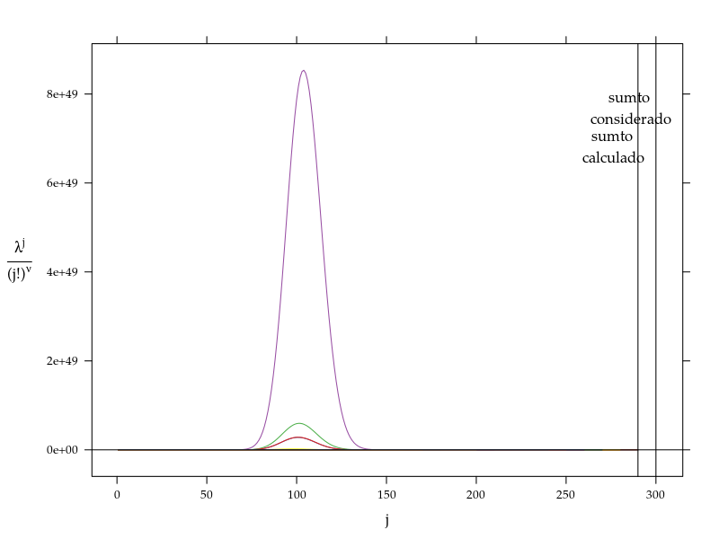

```r
## Um dos problemas computacionais do modelo COM-Poisson é a obtenção da
## constante de normalização Z. Assim uma visualização pós ajuste para
## verificar se o ajuste proporcionou uma densidade válida se faz
## necessária

## No modelo para o número de vagens viáveis
convergencez(m2C.nv)
```

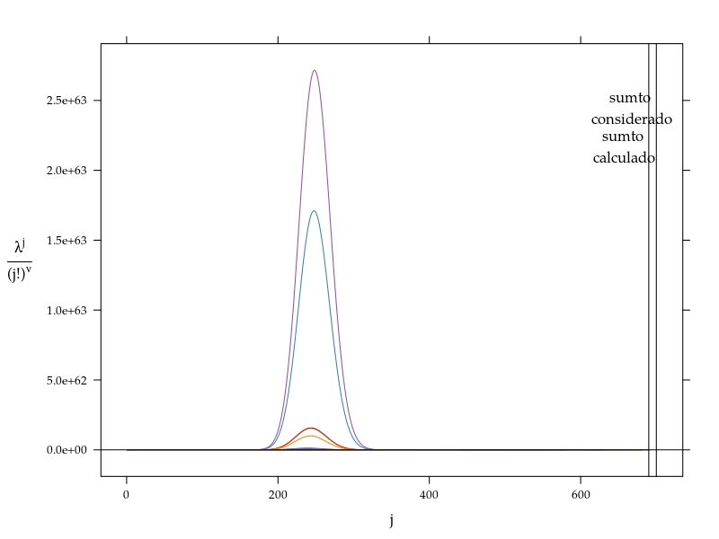

```r
## No modelo para o número de grão por parcela
convergencez(m2C.ng)
```

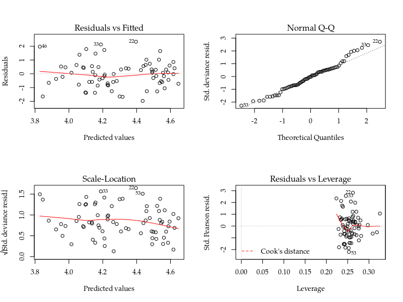

```r
## Dado que o modelo COM-Poisson leva as mesmas estimativas pontuais que
## o modelo Poisson a análise de diagnóstico padrão pode ser utilizada

## Avaliação do modelo para o número de vagens viáveis
par(mfrow = c(2, 2))
plot(m2P.nv)
```

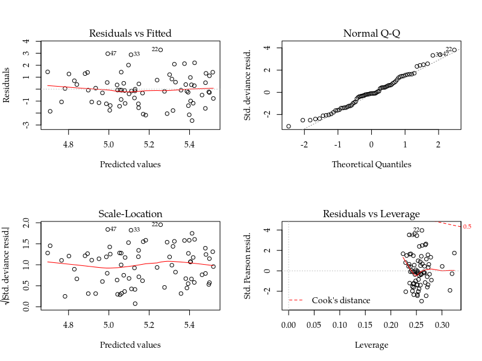

```r
## Avaliação do modelo para o número de grão por parcela
par(mfrow = c(2, 2))
plot(m2P.ng)
```

```r
## Testando a nulidade do parâmetro phi

##-------------------------------------------
## No modelo para o número de vagens viáveis

## Usando o ajuste Poisson
trv <- 2 * (logLik(m2C.nv) - logLik(m2P.nv))
attributes(trv) <- NULL
round(c(trv, pchisq(trv, 1, lower = FALSE)), digits = 5)
```

```
## [1] 0.57970 0.44643
```

```r
## Reajustando o COM-Poisson para phi = 0 (ou equivalente nu = 1)
m2Cfixed.nv <- cmp(f2.nv, data = soja, fixed = list("phi" = 0),
                   sumto = 300)
anova(m2C.nv, m2Cfixed.nv)
```

```
## Likelihood Ratio Tests
## Model 1: m2C.nv, [llcmp]: phi+(Intercept)+blocII+blocIII+
##           blocIV+blocV+umid50+umid62,5+K30+K60+K120+K180+
##           umid50:K30+umid62,5:K30+umid50:K60+umid62,5:K60+
##           umid50:K120+umid62,5:K120+umid50:K180+umid62,5:K180
## Model 2: m2Cfixed.nv, [llcmp]: (Intercept)+blocII+blocIII+
##           blocIV+blocV+umid50+umid62,5+K30+K60+K120+K180+
##           umid50:K30+umid62,5:K30+umid50:K60+umid62,5:K60+
##           umid50:K120+umid62,5:K120+umid50:K180+umid62,5:K180
##   Tot Df Deviance  Chisq Df Pr(>Chisq)
## 1     20   518.65
## 2     19   519.23 0.5797  1     0.4464
```

```r
##-------------------------------------------
## No modelo para o número de grão por parcela

## Usando o ajuste Poisson
trv <- 2 * (logLik(m2C.ng) - logLik(m2P.ng))
attributes(trv) <- NULL
round(c(trv, pchisq(trv, 1, lower = FALSE)), digits = 5)
```

```
## [1] 12.04879  0.00052
```

```r
## Reajustando o COM-Poisson para phi = 0 (ou equivalente nu = 1)
m2Cfixed.ng <- cmp(f2.ng, data = soja, fixed = list("phi" = 0),
                   sumto = 700)
anova(m2C.ng, m2Cfixed.ng)
```

```
## Likelihood Ratio Tests
## Model 1: m2C.ng, [llcmp]: phi+(Intercept)+blocII+blocIII+
##           blocIV+blocV+umid50+umid62,5+K30+K60+K120+K180+
##           umid50:K30+umid62,5:K30+umid50:K60+umid62,5:K60+
##           umid50:K120+umid62,5:K120+umid50:K180+umid62,5:K180
## Model 2: m2Cfixed.ng, [llcmp]: (Intercept)+blocII+blocIII+
##           blocIV+blocV+umid50+umid62,5+K30+K60+K120+K180+
##           umid50:K30+umid62,5:K30+umid50:K60+umid62,5:K60+
##           umid50:K120+umid62,5:K120+umid50:K180+umid62,5:K180
##   Tot Df Deviance  Chisq Df Pr(>Chisq)
## 1     20   631.29
## 2     19   643.34 12.049  1  0.0005183 ***
## ---
## Signif. codes:  0 '***' 0.001 '**' 0.01 '*' 0.05 '.' 0.1 ' ' 1
```

[output not shown]

[output not shown]

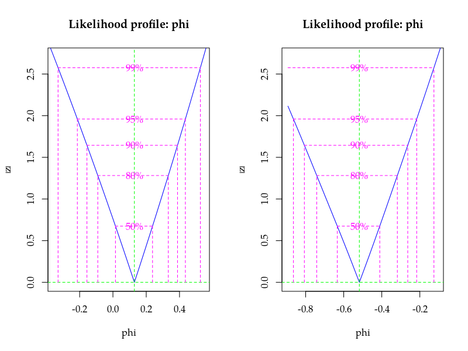

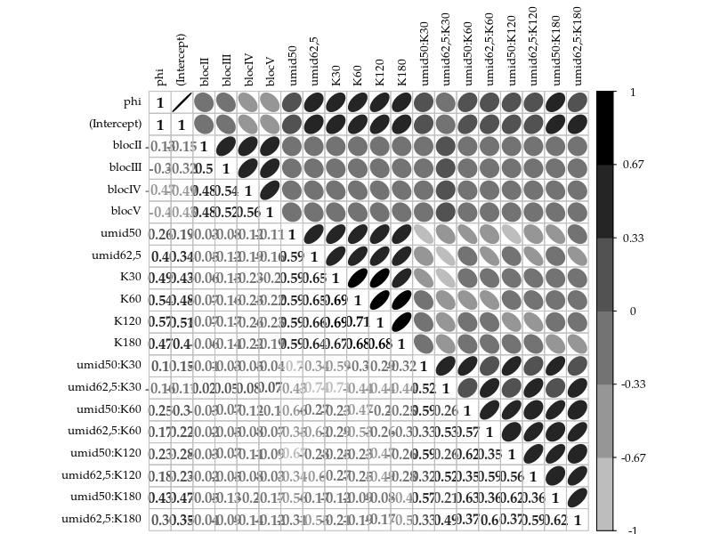

```r
## Verificando a matriz de variâncias e covariâncias

##-------------------------------------------
## No modelo para o número de vagens viáveis
Vcov.nv <- vcov(m2C.nv)
Corr <- cov2cor(Vcov.nv)

corrplot.mixed(Corr, lower = "number", upper = "ellipse",
               diag = "l", tl.pos = "lt", tl.col = "black",
               tl.cex = 0.8, col = brewer.pal(9, "Greys")[-(1:3)])
```

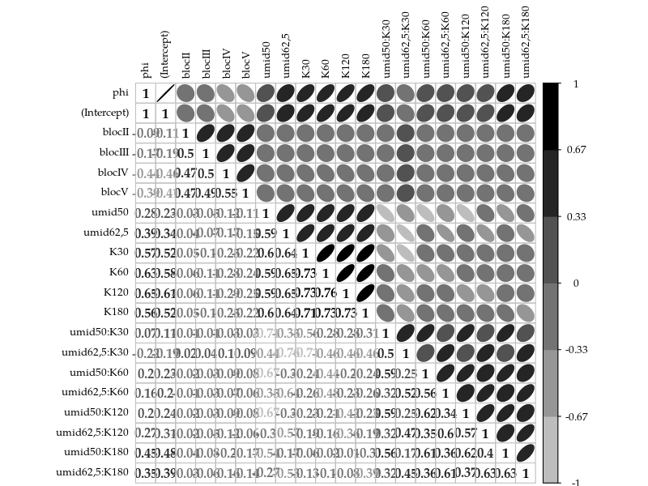

```r
##-------------------------------------------
## No modelo para o número de grão por parcela
Vcov.ng <- vcov(m2C.ng)
Corr <- cov2cor(Vcov.ng)

corrplot.mixed(Corr, lower = "number", upper = "ellipse",
               diag = "l", tl.pos = "lt", tl.col = "black",
               tl.cex = 0.8, col = brewer.pal(9, "Greys")[-(1:3)])
```

## Predição

```r
## Predição pontual/intervalar
pred <- with(soja,
             expand.grid(
                 bloc = factor(levels(bloc)[1], levels = levels(bloc)),
                 umid = levels(umid),
                 K = levels(K)
                 ## nvag = 1
             ))
qn <- qnorm(0.975) * c(fit = 0, lwr = -1, upr = 1)

## Definindos as matrizes de delineamento

## Do modelo com interação
f2.ng; f2.ng[-2]
```

```
## ngra ~ bloc + umid * K
```

```
## ~bloc + umid * K
```

```r
X2 <- model.matrix(f2.ng[-2], data = pred)

## Como não temos interesse na interpretação dos efeitos de blocos
## tomaremos a média desses efeitos para predição
bl2 <- attr(X2, "assign") == 1
X2[, bl2] <- X2[, bl2] * 0 + 1/(sum(bl2) + 1)
head(X2)
```

```
##   (Intercept) blocII blocIII blocIV blocV umid50 umid62,5 K30 K60
## 1           1    0.2     0.2    0.2   0.2      0        0   0   0
## 2           1    0.2     0.2    0.2   0.2      1        0   0   0
## 3           1    0.2     0.2    0.2   0.2      0        1   0   0
## 4           1    0.2     0.2    0.2   0.2      0        0   1   0
## 5           1    0.2     0.2    0.2   0.2      1        0   1   0
## 6           1    0.2     0.2    0.2   0.2      0        1   1   0
##   K120 K180 umid50:K30 umid62,5:K30 umid50:K60 umid62,5:K60
## 1    0    0          0            0          0            0
## 2    0    0          0            0          0            0
## 3    0    0          0            0          0            0
## 4    0    0          0            0          0            0
## 5    0    0          1            0          0            0
## 6    0    0          0            1          0            0
##   umid50:K120 umid62,5:K120 umid50:K180 umid62,5:K180
## 1           0             0           0             0
## 2           0             0           0             0
## 3           0             0           0             0
## 4           0             0           0             0
## 5           0             0           0             0
## 6           0             0           0             0
```

```r
## Do modelo aditivo, apenas retiramos os termos referentes ao efeito de
## interação
X1 <- X2[, attr(X2, "assign") != 4]
head(X1)
```

```
##   (Intercept) blocII blocIII blocIV blocV umid50 umid62,5 K30 K60
## 1           1    0.2     0.2    0.2   0.2      0        0   0   0
## 2           1    0.2     0.2    0.2   0.2      1        0   0   0
## 3           1    0.2     0.2    0.2   0.2      0        1   0   0
## 4           1    0.2     0.2    0.2   0.2      0        0   1   0
## 5           1    0.2     0.2    0.2   0.2      1        0   1   0
## 6           1    0.2     0.2    0.2   0.2      0        1   1   0
##   K120 K180
## 1    0    0
## 2    0    0
## 3    0    0
## 4    0    0
## 5    0    0
## 6    0    0
```

```r
library(multcomp)
```

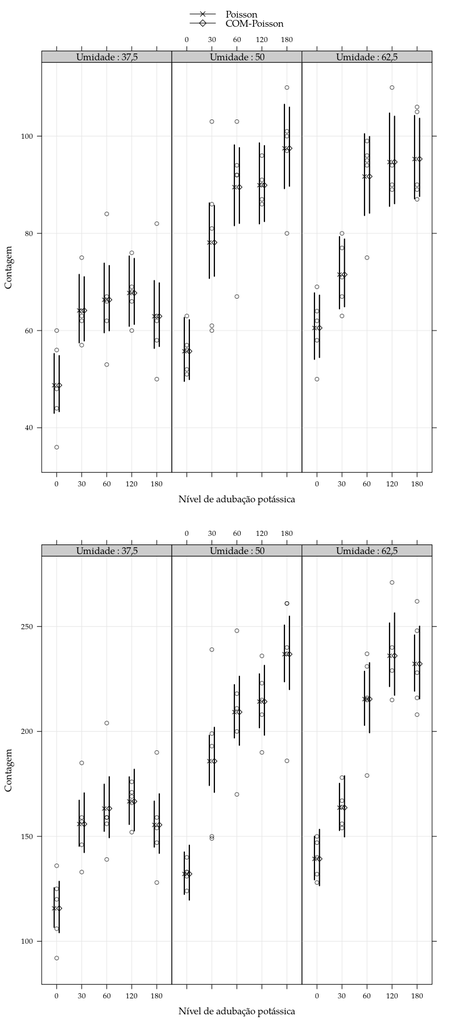

```r
##-------------------------------------------
## Considerando a Poisson

## No modelo para o número de vagens
aux <- exp(confint(glht(m2P.nv, linfct = X2),
               calpha = univariate_calpha())$confint)
colnames(aux) <- c("fit", "lwr", "upr")
aux <- data.frame(modelo = "Poisson", aux)
predP.nv <- cbind(pred, aux)

## No modelo para o número de grãos por parcela
aux <- exp(confint(glht(m2P.ng, linfct = X2),
               calpha = univariate_calpha())$confint)
colnames(aux) <- c("fit", "lwr", "upr")
aux <- data.frame(modelo = "Poisson", aux)
predP.ng <- cbind(pred, aux)

##----------------------------------------------------------------------
## Considerando a COM-Poisson

## No modelo para o número de vagens
aux <- predict(m2C.nv, newdata = X2, type = "response",
               interval = "confidence")
aux <- data.frame(modelo = "COM-Poisson", aux)
predC.nv <- cbind(pred, aux)

## No modelo para o número de grãos por parcela
aux <- predict(m2C.ng, newdata = X2, type = "response",
               interval = "confidence")
aux <- data.frame(modelo = "COM-Poisson", aux)
predC.ng <- cbind(pred, aux)

##-------------------------------------------
## Visualizando os valores preditos intervalares pelos dois modelos
da.nv <- rbind(predP.nv, predC.nv)
da.nv <- da.nv[with(da.nv, order(umid, K, modelo)), ]

da.ng <- rbind(predP.ng, predC.ng)
da.ng <- da.ng[with(da.ng, order(umid, K, modelo)), ]

source(paste0("https://gitlab.c3sl.ufpr.br/leg/legTools/raw/",
              "issue%2315/R/panel.segplot.by.R"))

key <- list(type = "o", divide = 1,
            lines = list(pch = 1:nlevels(da.nv$modelo) + 3, lty = 1),
            text = list(c("Poisson", "COM-Poisson")))

xy1 <- xyplot(nvag ~ K | umid, data = soja,
       xlab = "Nível de adubação potássica",
       ylab = "Contagem",
       type = c("p", "g"), alpha = 0.7,
       key = key,
       layout = c(NA, 1),
       as.table = TRUE,
       strip = strip.custom(
           strip.names = TRUE, var.name = "Umidade")) +
    as.layer(
        segplot(
            K ~ lwr + upr | umid,
            centers = fit, groups = modelo, data = da.nv,
            grid = TRUE, horizontal = FALSE, draw = FALSE,
            lwd = 2, pch = 1:nlevels(da$modelo) + 3,
            panel = panel.segplot.by, f = 0.1, as.table = TRUE)
    )

xy2 <- xyplot(ngra ~ K | umid, data = soja,
       xlab = "Nível de adubação potássica",
       ylab = "Contagem",
       type = c("p", "g"), alpha = 0.7,
       ## key = key,
       layout = c(NA, 1),
       as.table = TRUE,
       strip = strip.custom(
           strip.names = TRUE, var.name = "Umidade")) +
    as.layer(
        segplot(
            K ~ lwr + upr | umid,
            centers = fit, groups = modelo, data = da.ng,
            grid = TRUE, horizontal = FALSE, draw = FALSE,
            lwd = 2, pch = 1:nlevels(da$modelo) + 3,
            panel = panel.segplot.by, f = 0.1, as.table = TRUE)
    )

## x11(width = 10, height = 50)
print(xy1, split = c(1, 1, 1, 2), more = TRUE)
print(xy2, split = c(1, 2, 1, 2), more = FALSE)
```

# Capulhos de algodão sob efeito de desfolha

```r
data(capdesfo)
str(capdesfo)
```

```
## 'data.frame':    125 obs. of  4 variables:
##  $ est : Factor w/ 5 levels "vegetativo","botão floral",..: 1 1 1 1 1 1 1 1 1 1 ...
##  $ des : num  0 0 0 0 0 0.25 0.25 0.25 0.25 0.25 ...
##  $ rept: int  1 2 3 4 5 1 2 3 4 5 ...
##  $ ncap: int  10 9 8 8 10 11 9 10 10 10 ...
```

```r
## help(capdesfo)
```

Experimento conduzido sob delineamento inteiramente casualizado em casa de vegetação onde avaliou-se o número de capulhos produzidos por plantas de algodão submetidas à níveis de desfolha artificial de remoção foliar em combinação com o estágio fenológico no qual a desfolha foi aplicada.

- `est`: Estágio fenológico com cinco níveis (vegetativo, botão floral, florecimento, maça, capulho);
- `des`: Nível de desfolha artificial de remoção foliar (0, 25, 50, 75, 100%);
- `ncap`: Número de capulhos de algodão produzidos ao final da ciclo cultura.

## Análise Exploratória

```r
## Experimento balanceado
xtabs(~est + des, data = capdesfo)
```

```
##               des
## est            0 0.25 0.5 0.75 1
##   vegetativo   5    5   5    5 5
##   botão floral 5    5   5    5 5
##   florecimento 5    5   5    5 5
##   maça         5    5   5    5 5
##   capulho      5    5   5    5 5
```

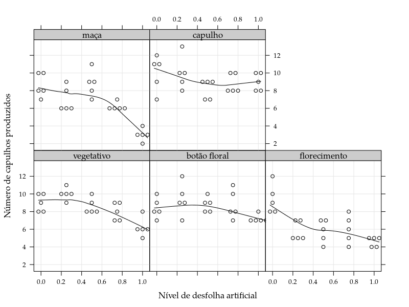

```r
(xy <- xyplot(ncap ~ des | est,
             data = capdesfo,
             xlab = "Nível de desfolha artificial",
             ylab = "Número de capulhos produzidos",
             type = c("p", "g", "smooth"),
             panel = panel.beeswarm,
             r = 0.05))
```

```r
## Avaliando preliminarmente suposição de equidispersão
(mv <- aggregate(ncap ~ est + des, data = capdesfo,
                 FUN = function(x) c(mean = mean(x), var = var(x))))
```

```
##             est  des ncap.mean ncap.var
## 1    vegetativo 0.00       9.0      1.0
## 2  botão floral 0.00       8.4      1.3
## 3  florecimento 0.00       9.4      2.8
## 4          maça 0.00       8.6      1.8
## 5       capulho 0.00      10.0      4.0
## 6    vegetativo 0.25      10.0      0.5
## 7  botão floral 0.25       9.4      3.3
## 8  florecimento 0.25       5.8      1.2
## 9          maça 0.25       7.0      2.0
## 10      capulho 0.25      10.0      3.5
## 11   vegetativo 0.50       8.6      0.8
## 12 botão floral 0.50       8.8      0.7
## 13 florecimento 0.50       5.8      1.7
## 14         maça 0.50       8.8      2.2
## 15      capulho 0.50       8.2      1.2
## 16   vegetativo 0.75       8.0      1.0
## 17 botão floral 0.75       8.8      2.7
## 18 florecimento 0.75       6.0      2.5
## 19         maça 0.75       6.2      0.2
## 20      capulho 0.75       8.8      1.2
## 21   vegetativo 1.00       6.2      1.2
## 22 botão floral 1.00       7.2      0.2
## 23 florecimento 1.00       4.6      0.3
## 24         maça 1.00       3.0      0.5
## 25      capulho 1.00       9.0      1.0
```

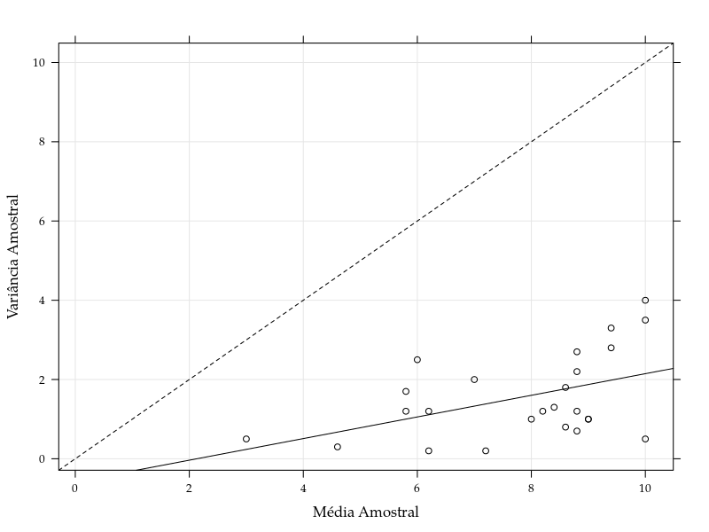

```r
xlim <- ylim <- extendrange(c(mv$ncap), f = 0.05)
xyplot(ncap[, "var"] ~ ncap[, "mean"],
       data = mv,
       xlim = xlim, ylim = ylim,
       ylab = "Variância Amostral",
       xlab = "Média Amostral",
       panel = function(x, y) {
           panel.xyplot(x, y, type = c("p", "r"), grid = TRUE)
           panel.abline(a = 0, b = 1, lty = 2)
       })
```

## Ajuste dos modelos

```r
## Preditores considerados
f1 <- ncap ~ 1
f2 <- ncap ~ des + I(des^2)
f3 <- ncap ~ est:des + I(des^2)
f4 <- ncap ~ est:(des + I(des^2))

## Ajustando os modelos Poisson
m1P <- glm(f1, data = capdesfo, family = poisson)
m2P <- glm(f2, data = capdesfo, family = poisson)
m3P <- glm(f3, data = capdesfo, family = poisson)
m4P <- glm(f4, data = capdesfo, family = poisson)

## Ajustando os modelos COM-Poisson
m1C <- cmp(f1, data = capdesfo)
m2C <- cmp(f2, data = capdesfo)
m3C <- cmp(f3, data = capdesfo)
m4C <- cmp(f4, data = capdesfo)
```

## Comparação dos ajustes

```r
## Verossimilhancas dos modelos ajustados
cbind("Poisson" = sapply(list(m1P, m2P, m3P, m4P), logLik),
      "COM-Poisson" = sapply(list(m1C, m2C, m3C, m4C), logLik))
```

```
##        Poisson COM-Poisson
## [1,] -279.9328   -272.4794
## [2,] -271.3543   -256.0893
## [3,] -258.6741   -220.1977
## [4,] -255.8031   -208.2500
```

```r
## Teste de razão de verossimilhanças
anova(m1P, m2P, m3P, m4P, test = "Chisq")
```

```
## Analysis of Deviance Table
##
## Model 1: ncap ~ 1
## Model 2: ncap ~ des + I(des^2)
## Model 3: ncap ~ est:des + I(des^2)
## Model 4: ncap ~ est:(des + I(des^2))
##   Resid. Df Resid. Dev Df Deviance  Pr(>Chi)
## 1       124     75.514
## 2       122     58.357  2   17.157 0.0001881 ***
## 3       118     32.997  4   25.360 4.258e-05 ***
## 4       114     27.255  4    5.742 0.2192611
## ---
## Signif. codes:  0 '***' 0.001 '**' 0.01 '*' 0.05 '.' 0.1 ' ' 1
```

```r
anova(m1C, m2C, m3C, m4C)
```

```
## Likelihood Ratio Tests
## Model 1: m1C, [llcmp]: phi+(Intercept)
## Model 2: m2C, [llcmp]: phi+(Intercept)+des+I(des^2)
## Model 3: m3C, [llcmp]: phi+(Intercept)+I(des^2)+
##           estvegetativo:des+estbotão floral:des+
##           estflorecimento:des+estmaça:des+estcapulho:des
## Model 4: m4C, [llcmp]: phi+(Intercept)+estvegetativo:des+
##           estbotão floral:des+estflorecimento:des+estmaça:des+
##           estcapulho:des+estvegetativo:I(des^2)+estbotão
##           floral:I(des^2)+estflorecimento:I(des^2)+
##           estmaça:I(des^2)+estcapulho:I(des^2)
##   Tot Df Deviance  Chisq Df Pr(>Chisq)
## 1      2   544.96
## 2      4   512.18 32.780  2  7.619e-08 ***
## 3      8   440.40 71.783  4  9.537e-15 ***
## 4     12   416.50 23.895  4  8.382e-05 ***
## ---
## Signif. codes:  0 '***' 0.001 '**' 0.01 '*' 0.05 '.' 0.1 ' ' 1
```

```r
## Estimativas dos parâmetros
summary(m4P)
```

```
##
## Call:
## glm(formula = f4, family = poisson, data = capdesfo)
##
## Deviance Residuals:
##      Min        1Q    Median        3Q       Max
## -1.06976  -0.31729  -0.02347   0.34779   1.27069
##
## Coefficients:
##                           Estimate Std. Error z value Pr(>|z|)
## (Intercept)               2.189560   0.063333  34.572   <2e-16 ***
## estvegetativo:des         0.436859   0.515560   0.847   0.3968
## estbotão floral:des       0.289715   0.507751   0.571   0.5683
## estflorecimento:des      -1.242481   0.603706  -2.058   0.0396 *
## estmaça:des               0.364871   0.565803   0.645   0.5190
## estcapulho:des            0.008949   0.503760   0.018   0.9858
## estvegetativo:I(des^2)   -0.805215   0.583915  -1.379   0.1679
## estbotão floral:I(des^2) -0.487850   0.566394  -0.861   0.3891
## estflorecimento:I(des^2)  0.672837   0.680195   0.989   0.3226
## estmaça:I(des^2)         -1.310346   0.672780  -1.948   0.0515 .
## estcapulho:I(des^2)      -0.019970   0.552505  -0.036   0.9712
## ---
## Signif. codes:  0 '***' 0.001 '**' 0.01 '*' 0.05 '.' 0.1 ' ' 1
##
## (Dispersion parameter for poisson family taken to be 1)
##
##     Null deviance: 75.514  on 124  degrees of freedom
## Residual deviance: 27.255  on 114  degrees of freedom
## AIC: 533.61
##
## Number of Fisher Scoring iterations: 4
```

```r
summary(m4C)
```

```
## Maximum likelihood estimation
##
## Call:
## bbmle::mle2(minuslogl = llcmp, start = start, data = list(y = y,
##     X = X, sumto = sumto), vecpar = TRUE)
##
## Coefficients:
##                           Estimate Std. Error z value     Pr(z)
## phi                       1.584701   0.127619 12.4174 < 2.2e-16 ***
## (Intercept)              10.896190   1.404117  7.7602 8.481e-15 ***
## estvegetativo:des         2.018067   1.140738  1.7691 0.0768791 .
## estbotão floral:des       1.342978   1.109141  1.2108 0.2259619
## estflorecimento:des      -5.749747   1.479754 -3.8856 0.0001021 ***
## estmaça:des               1.595068   1.229222  1.2976 0.1944168
## estcapulho:des            0.037665   1.087991  0.0346 0.9723840
## estvegetativo:I(des^2)   -3.723683   1.341879 -2.7750 0.0055206 **
## estbotão floral:I(des^2) -2.264620   1.254617 -1.8050 0.0710702 .
## estflorecimento:I(des^2)  3.133964   1.504322  2.0833 0.0372233 *
## estmaça:I(des^2)         -5.894220   1.611865 -3.6568 0.0002554 ***
## estcapulho:I(des^2)      -0.090159   1.193309 -0.0756 0.9397741
## ---
## Signif. codes:  0 '***' 0.001 '**' 0.01 '*' 0.05 '.' 0.1 ' ' 1
##
## -2 log L: 416.4999
```

## Avaliando modelo proposto

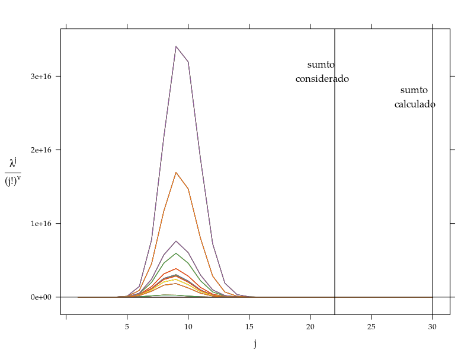

```r
## Um dos problemas computacionais do modelo COM-Poisson é a obtenção da
## constante de normalização Z. Assim uma visualização pós ajuste para
## verificar se o ajuste proporcionou uma densidade válida se faz
## necessária
convergencez(m4C)
```

```r
## Reajustando o modelo
logLik(m4C <- cmp(f4, data = capdesfo, sumto = 30))
```

```
## 'log Lik.' -208.25 (df=12)
```

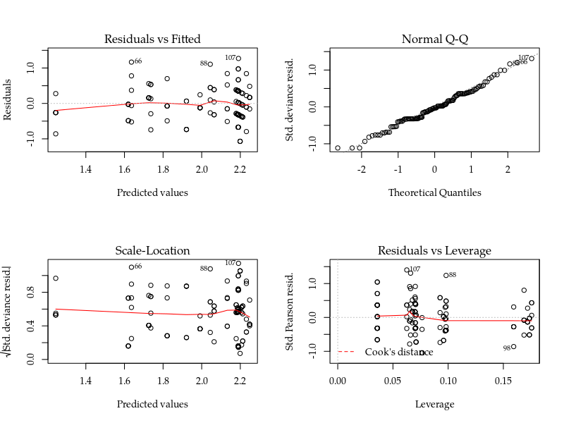

```r
## Dado que o modelo COM-Poisson leva as mesmas estimativas pontuais que
## o modelo Poisson a análise de diagnóstico padrão pode ser utilizada
par(mfrow = c(2, 2))
plot(m4P)
```

```r
##-------------------------------------------
## Testando a nulidade do parâmetro phi

## Usando o ajuste Poisson
trv <- 2 * (logLik(m4C) - logLik(m4P))
attributes(trv) <- NULL
round(c(trv, pchisq(trv, 1, lower = FALSE)), digits = 5)
```

```
## [1] 95.10632  0.00000
```

```r
## Reajustando o COM-Poisson para phi = 0 (ou equivalente nu = 1)
m4Cfixed <- cmp(f4, data = capdesfo, fixed = list("phi" = 0))
anova(m4C, m4Cfixed)
```

```
## Likelihood Ratio Tests
## Model 1: m4C, [llcmp]: phi+(Intercept)+estvegetativo:des+
##           estbotão floral:des+estflorecimento:des+estmaça:des+
##           estcapulho:des+estvegetativo:I(des^2)+estbotão
##           floral:I(des^2)+estflorecimento:I(des^2)+
##           estmaça:I(des^2)+estcapulho:I(des^2)
## Model 2: m4Cfixed, [llcmp]: (Intercept)+estvegetativo:des+
##           estbotão floral:des+estflorecimento:des+estmaça:des+
##           estcapulho:des+estvegetativo:I(des^2)+estbotão
##           floral:I(des^2)+estflorecimento:I(des^2)+
##           estmaça:I(des^2)+estcapulho:I(des^2)
##   Tot Df Deviance  Chisq Df Pr(>Chisq)
## 1     12    416.5
## 2     11    511.6 95.096  1  < 2.2e-16 ***
## ---
## Signif. codes:  0 '***' 0.001 '**' 0.01 '*' 0.05 '.' 0.1 ' ' 1
```

```r
## Via perfil de log-verossimilhança
perf <- profile(m4C, which = "phi")
confint(perf)
```

```
##    2.5 %   97.5 %
## 1.323327 1.824517
```

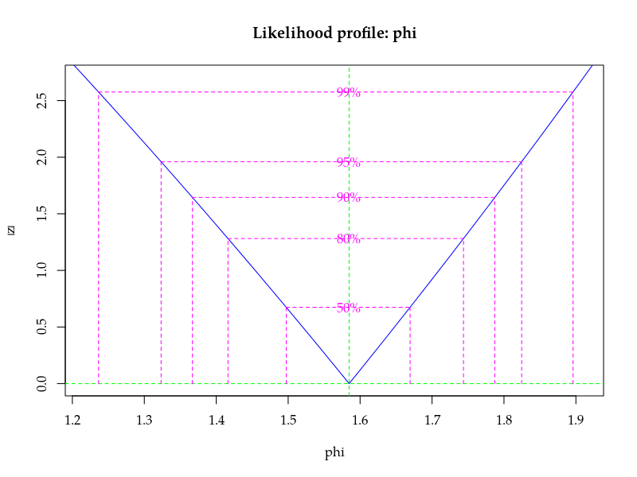

```r
plot(perf)
```

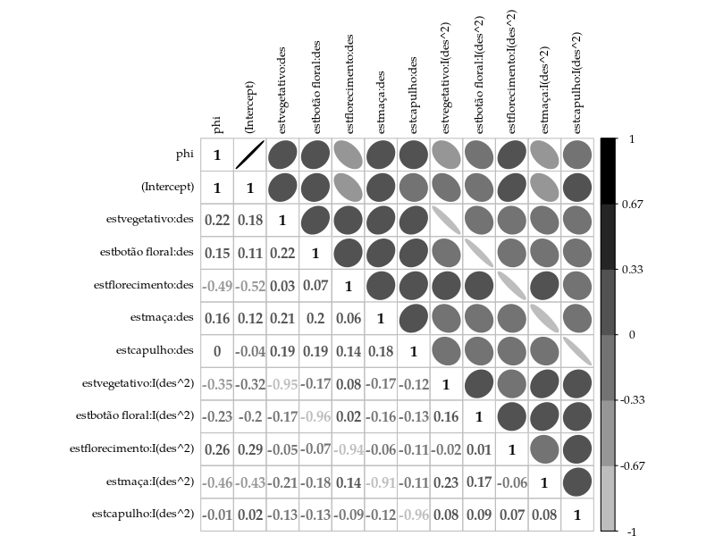

```r
##-------------------------------------------
## Verificando a matriz ve variâncias e covariâncias
Vcov <- vcov(m4C)
Corr <- cov2cor(Vcov)

library(corrplot)
corrplot.mixed(Corr, lower = "number", upper = "ellipse",
               diag = "l", tl.pos = "lt", tl.col = "black",
               tl.cex = 0.8, col = brewer.pal(9, "Greys")[-(1:3)])
```

## Predição

```r
## Predição pontual/intervalar
pred <- with(capdesfo,
             expand.grid(
                 est = levels(est),
                 des = seq(min(des), max(des), l = 20)
             ))
qn <- qnorm(0.975) * c(fit = 0, lwr = -1, upr = 1)

##-------------------------------------------
## Considerando a Poisson
aux <- predict(m4P, newdata = pred, se.fit = TRUE)
aux <- with(aux, exp(fit + outer(se.fit, qn, FUN = "*")))
aux <- data.frame(modelo = "Poisson", aux)
predP <- cbind(pred, aux)

##-------------------------------------------
## Considerando a COM-Poisson
f4; f4[-2]
```

```
## ncap ~ est:(des + I(des^2))
```

```
## ~est:(des + I(des^2))
```

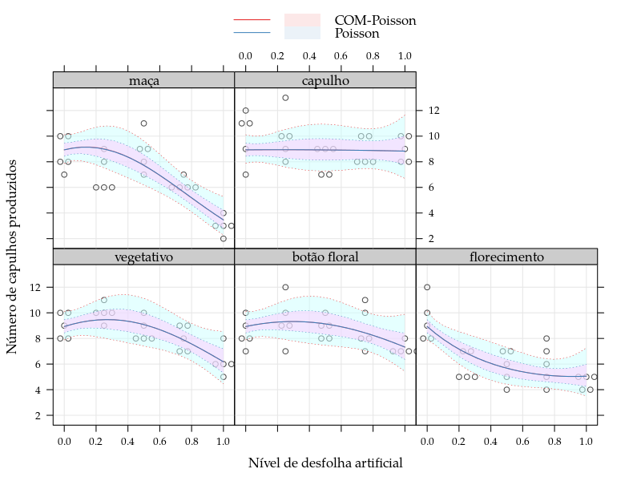

```r
X <- model.matrix(f4[-2], data = pred)

aux <- predict(m4C, newdata = X, type = "response",
               interval = "confidence")
aux <- data.frame(modelo = "COM-Poisson", aux)
predC <- cbind(pred, aux)

##-------------------------------------------
## Visualizando os valores preditos intervalares pelos dois modelos
da <- rbind(predP, predC)

## Legenda
cols <- trellis.par.get("superpose.line")$col[1:2]
key <- list(
    lines = list(lty = 1, col = cols),
    rect = list(col = cols, alpha = 0.1, lty = 3, border = NA),
    text = list(c("COM-Poisson", "Poisson")))

## Gráfico dos valores preditos e IC de 95% para média
update(xy, type = c("p", "g"), key = key, alpha = 0.7) +
    as.layer(xyplot(fit ~ des | est,
                    groups = modelo,
                    data = da,
                    type = "l",
                    ly = da$lwr,
                    uy = da$upr,
                    cty = "bands",
                    alpha = 0.5,
                    prepanel = prepanel.cbH,
                    panel.groups = panel.cbH,
                    panel = panel.superpose))
```

## Reparametrização para a média

### Definindo a log-verossimilhança

```r
## Reparametriza para a média (aproximada)
llcmp3 <- function (params, y, X, offset = NULL, sumto = 50) {
    betas <- params[-1]
    phi <- params[1]
    nu <- exp(phi)
    if (is.null(offset))
        offset <- 0
    ##-------------------------------------------
    ## Reparametrização para a média
    mu <- exp(X %*% betas)
    Xb <- nu * log(mu + (nu - 1)/(2 * nu))
    ##-------------------------------------------
    i <- 0:sumto
    zs <- sapply(Xb, function(loglambda) sum(exp(i * loglambda -
                                                 nu * lfactorial(i))))
    Z <- sum(log(zs))
    ll <- sum(y * Xb - nu * lfactorial(y)) - Z
    return(-ll)
}
```

### Definindo a função de ajuste

```r
## Modifica framework para llcmp3
cmp3 <- function (formula, data, start = NULL, sumto = NULL, ...) {
    frame <- model.frame(formula, data)
    terms <- attr(frame, "terms")
    y <- model.response(frame)
    X <- model.matrix(terms, frame)
    ## off <- model.offset(frame)
    ## if (is.null(sumto))
    ##     sumto <- ceiling(max(y)^1.5)
    if (is.null(start)) {
        m0 <- glm.fit(x = X, y = y, family = poisson())
        start <- c(phi = 0, m0$coefficients)
    }
    bbmle::parnames(llcmp3) <- names(start)
    model <- bbmle::mle2(llcmp3, start = start, data = list(y = y,
        X = X), vecpar = TRUE, ...)
    return(model)
}
```

## Ajustando o modelo reparametrizado para a média

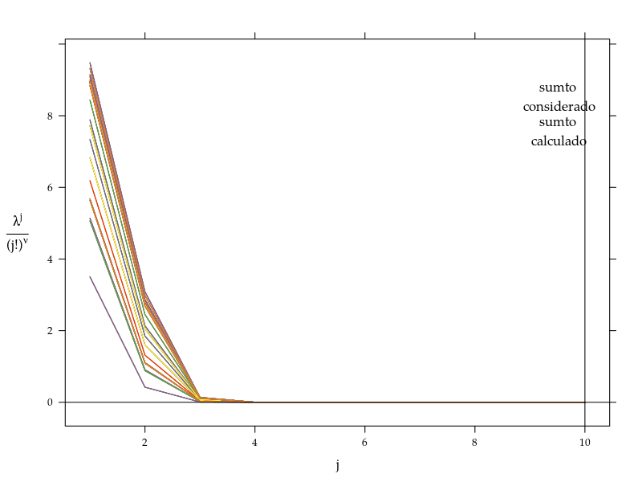

```r
## Ajustando o modelo
m4C2 <- cmp3(f4, data = capdesfo)
convergencez(m4C2)
```

```r
## Perfis de verossimilhança para phi
perf <- profile(m4C2, which = "phi")
confint(perf)
```

```
##    2.5 %   97.5 %
## 1.320391 1.821609
```

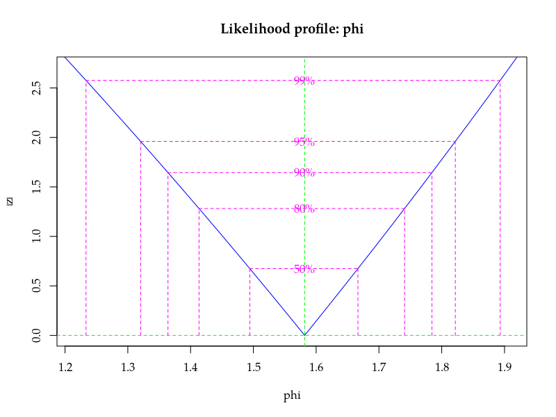

```r
plot(perf)
```

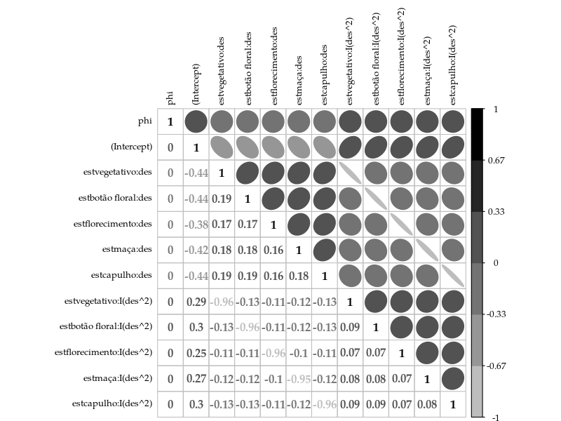

```r
##-------------------------------------------
## Verificando a matriz de variâncias e covariâncias
Vcov <- vcov(m4C2)
Corr <- cov2cor(Vcov)

corrplot.mixed(Corr, lower = "number", upper = "ellipse",
               diag = "l", tl.pos = "lt", tl.col = "black",
               tl.cex = 0.8, col = brewer.pal(9, "Greys")[-(1:3)])
```

```r
X <- m4C2@data$X
mu <- c(exp(X %*% coef(m4C2)[-1]))

##-------------------------------------------
## Considerando a COM-Poisson reparametrizada para a média
f4; f4[-2]
```

```
## ncap ~ est:(des + I(des^2))
```

```
## ~est:(des + I(des^2))
```

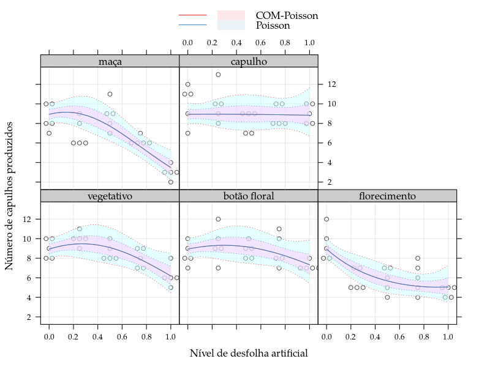

```r
X <- model.matrix(f4[-2], data = pred)

betas <- coef(m4C2)[-1]
phi <- coef(m4C2)[1]
logmu <- X %*% betas

## Obtendo os erros padrão das estimativas
##   Obs.: Deve-se usar a matriz de variâncias e covariâncias
##   condicional, pois os parâmetros de locação (betas) e dispersão
##   (phi) não são ortogonais.
Vc <- Vcov[-1, -1] - Vcov[-1, 1] %*% solve(Vcov[1, 1]) %*% Vcov[1, -1]
U <- chol(Vc)
se <- sqrt(apply(X %*% t(U), MARGIN = 1, FUN = function(x) {
    sum(x^2)
}))

aux <- exp(c(logmu) + outer(se, qn, FUN = "*"))
aux <- data.frame(modelo = "COM-Poisson", aux)
predC2 <- cbind(pred, aux)

##-------------------------------------------
## Visualizando os valores preditos intervalares pelos dois modelos
da <- rbind(predP, predC2)

update(xy, type = c("p", "g"), key = key, alpha = 0.7) +
    as.layer(xyplot(fit ~ des | est,
                    groups = modelo,
                    data = da,
                    type = "l",
                    ly = da$lwr,
                    uy = da$upr,
                    cty = "bands",
                    alpha = 0.5,
                    prepanel = prepanel.cbH,
                    panel.groups = panel.cbH,
                    panel = panel.superpose))
```

# Ocorrência de ninfas de mosca-branca em variedades de soja

```r
data(ninfas)
str(ninfas)
```

```
## 'data.frame':    240 obs. of  8 variables:
##  $ data : Date, format: "2009-12-11" ...
##  $ dias : int  0 0 0 0 0 0 0 0 0 0 ...
##  $ cult : Factor w/ 10 levels "BRS 239","BRS 243 RR",..: 3 3 3 3 2 2 2 2 4 4 ...
##  $ bloco: Factor w/ 4 levels "I","II","III",..: 1 2 3 4 1 2 3 4 1 2 ...
##  $ nsup : int  168 30 28 6 31 4 3 48 100 54 ...
##  $ nmed : int  71 46 36 1 22 6 12 76 50 15 ...
##  $ ninf : int  39 22 7 31 28 10 27 13 34 7 ...
##  $ ntot : int  278 98 71 38 81 20 42 137 184 76 ...
```

```r
## help(ninfas)
```

Experimento conduzido em casa de vegetação sob o delineamento de blocos casualizados. No experimento foram avaliadas plantas de diferentes cultivares de soja contabilizando o número de ninfas de mosca-branca nos folíolos dos terços superior, médio e inferior das plantas. As avaliações ocorreram em 6 datas dentre os 38 dias do estudo.

```r
## Somente as cultivares que contém BRS na identificação
ninfas <- droplevels(subset(ninfas, grepl("BRS", x = cult)))

## Categorizando a variável dias em aval
ninfas$aval <- factor(ninfas$dias)

str(ninfas)
```

```
## 'data.frame':    96 obs. of  9 variables:
##  $ data : Date, format: "2009-12-11" ...
##  $ dias : int  0 0 0 0 0 0 0 0 0 0 ...
##  $ cult : Factor w/ 4 levels "BRS 239","BRS 243 RR",..: 3 3 3 3 2 2 2 2 4 4 ...
##  $ bloco: Factor w/ 4 levels "I","II","III",..: 1 2 3 4 1 2 3 4 1 2 ...
##  $ nsup : int  168 30 28 6 31 4 3 48 100 54 ...
##  $ nmed : int  71 46 36 1 22 6 12 76 50 15 ...
##  $ ninf : int  39 22 7 31 28 10 27 13 34 7 ...
##  $ ntot : int  278 98 71 38 81 20 42 137 184 76 ...
##  $ aval : Factor w/ 6 levels "0","8","13","22",..: 1 1 1 1 1 1 1 1 1 1 ...
```

Assim as variáveis consideradas são definidas como:

- `bloco`: Fator com 4 níveis que representam os blocos utilizados para controle de variação local.
- `cult`: Fator com a identificação da cultivar de soja. Foram 4 cultivares (com prefixo BRS).
- `aval`: Fator que indica o número de dias, após o início do experimento em que realizou-se as avaliações. Houve avaliações em 6 datas.

## Análise Exploratória

```r
## Experimento balanceado
xtabs(~aval + cult, data = ninfas)
```

```
##     cult
## aval BRS 239 BRS 243 RR BRS 245 RR BRS 246 RR
##   0        4          4          4          4
##   8        4          4          4          4
##   13       4          4          4          4
##   22       4          4          4          4
##   31       4          4          4          4
##   38       4          4          4          4
```

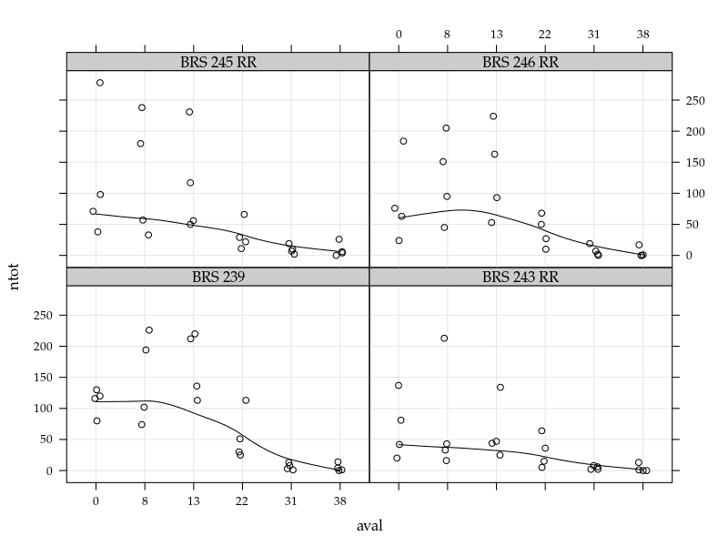

```r
(xy <- xyplot(ntot ~ aval | cult,
              data = ninfas,
              type = c("p", "g", "smooth"),
              jitter.x = TRUE))
```

```r
## Avaliando preliminarmente suposição de equidispersão
(mv <- aggregate(ntot ~ data + cult, data = ninfas,
                 FUN = function(x) c(mean = mean(x), var = var(x))))
```

```
##          data       cult   ntot.mean    ntot.var
## 1  2009-12-11    BRS 239   111.50000   475.66667
## 2  2009-12-19    BRS 239   149.00000  5262.66667
## 3  2009-12-24    BRS 239   170.25000  2889.58333
## 4  2010-01-02    BRS 239    54.75000  1634.91667
## 5  2010-01-11    BRS 239     6.25000    28.91667
## 6  2010-01-18    BRS 239     4.75000    40.91667
## 7  2009-12-11 BRS 243 RR    70.00000  2631.33333
## 8  2009-12-19 BRS 243 RR    76.25000  8435.58333
## 9  2009-12-24 BRS 243 RR    62.50000  2367.00000
## 10 2010-01-02 BRS 243 RR    30.00000   680.66667
## 11 2010-01-11 BRS 243 RR     4.50000     9.00000
## 12 2010-01-18 BRS 243 RR     3.50000    40.33333
## 13 2009-12-11 BRS 245 RR   121.25000 11522.25000
## 14 2009-12-19 BRS 245 RR   127.00000  9622.00000
## 15 2009-12-24 BRS 245 RR   113.50000  7052.33333
## 16 2010-01-02 BRS 245 RR    32.00000   568.66667
## 17 2010-01-11 BRS 245 RR     9.50000    51.00000
## 18 2010-01-18 BRS 245 RR     9.00000   134.66667
## 19 2009-12-11 BRS 246 RR    86.75000  4691.58333
## 20 2009-12-19 BRS 246 RR   124.00000  4790.66667
## 21 2009-12-24 BRS 246 RR   133.25000  5726.91667
## 22 2010-01-02 BRS 246 RR    38.75000   648.91667
## 23 2010-01-11 BRS 246 RR     7.00000    72.66667
## 24 2010-01-18 BRS 246 RR     4.50000    69.66667
```

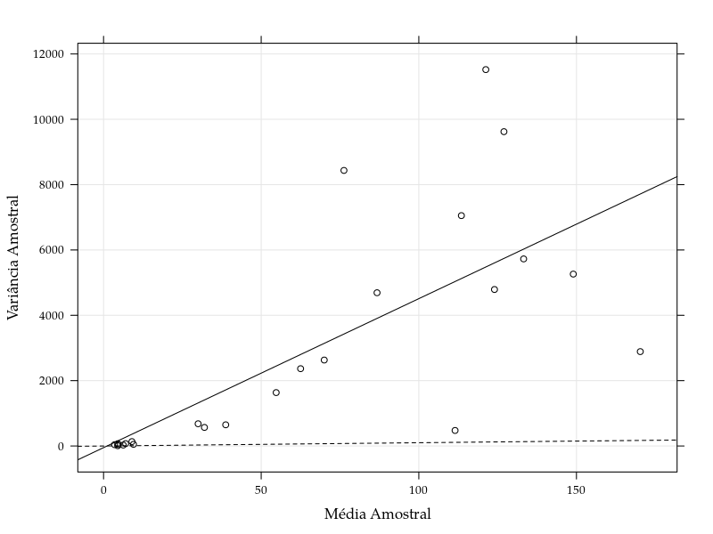

```r
xlim <- ylim <- extendrange(c(mv$ntot), f = 0.05)
xyplot(ntot[, "var"] ~ ntot[, "mean"],
       data = mv,
       ## xlim = xlim,  ylim = ylim,
       ylab = "Variância Amostral",
       xlab = "Média Amostral",
       panel = function(x, y) {
           panel.xyplot(x, y, type = c("p", "r"), grid = TRUE)
           panel.abline(a = 0, b = 1, lty = 2)
       })
```

## Ajuste dos modelos

```r
## Preditores considerados
f1 <- ntot ~ bloco + cult + aval
f2 <- ntot ~ bloco + cult * aval

## Ajustando os modelos Poisson
m1P <- glm(f1, data = ninfas, family = poisson)
m2P <- glm(f2, data = ninfas, family = poisson)

## Ajustando os modelos COM-Poisson
m1C <- cmp(f1, data = ninfas, sumto = 800)
m2C <- cmp(f2, data = ninfas, sumto = 800)
```

## Comparação dos ajustes

```r
## Verossimilhancas dos modelos ajustados
cbind("Poisson" = sapply(list(m1P, m2P), logLik),
      "COM-Poisson" = sapply(list(m1C, m2C), logLik))
```

```
##        Poisson COM-Poisson
## [1,] -922.9782   -410.4441
## [2,] -879.2287   -407.1332
```

```r
## Teste de razão de verossimilhanças
anova(m1P, m2P, test = "Chisq")
```

```
## Analysis of Deviance Table
##
## Model 1: ntot ~ bloco + cult + aval
## Model 2: ntot ~ bloco + cult * aval
##   Resid. Df Resid. Dev Df Deviance  Pr(>Chi)
## 1        84     1371.3
## 2        69     1283.8 15   87.499 2.897e-12 ***
## ---
## Signif. codes:  0 '***' 0.001 '**' 0.01 '*' 0.05 '.' 0.1 ' ' 1
```

```r
anova(m1C, m2C)
```

```
## Likelihood Ratio Tests
## Model 1: m1C, [llcmp]: phi+(Intercept)+blocoII+blocoIII+
##           blocoIV+cultBRS 243 RR+cultBRS 245 RR+cultBRS 246 RR+
##           aval8+aval13+aval22+aval31+aval38
## Model 2: m2C, [llcmp]: phi+(Intercept)+blocoII+blocoIII+
##           blocoIV+cultBRS 243 RR+cultBRS 245 RR+cultBRS 246 RR+
##           aval8+aval13+aval22+aval31+aval38+cultBRS 243
##           RR:aval8+cultBRS 245 RR:aval8+cultBRS 246 RR:aval8+
##           cultBRS 243 RR:aval13+cultBRS 245 RR:aval13+cultBRS 246
##           RR:aval13+cultBRS 243 RR:aval22+cultBRS 245 RR:aval22+
##           cultBRS 246 RR:aval22+cultBRS 243 RR:aval31+cultBRS 245
##           RR:aval31+cultBRS 246 RR:aval31+cultBRS 243 RR:aval38+
##           cultBRS 245 RR:aval38+cultBRS 246 RR:aval38
##   Tot Df Deviance  Chisq Df Pr(>Chisq)
## 1     13   820.89
## 2     28   814.27 6.6218 15     0.9673
```

```r
## Estimativas dos parâmetros
summary(m1P)
```

```
##
## Call:
## glm(formula = f1, family = poisson, data = ninfas)
##
## Deviance Residuals:
##      Min        1Q    Median        3Q       Max
## -13.2911   -3.0119   -0.7386    1.7743   12.3560
##
## Coefficients:
##                Estimate Std. Error z value Pr(>|z|)
## (Intercept)     5.33397    0.03480 153.262  < 2e-16 ***
## blocoII        -0.52019    0.03228 -16.114  < 2e-16 ***
## blocoIII       -0.81268    0.03555 -22.857  < 2e-16 ***
## blocoIV        -0.99360    0.03792 -26.204  < 2e-16 ***
## cultBRS 243 RR -0.69921    0.03894 -17.954  < 2e-16 ***
## cultBRS 245 RR -0.18595    0.03332  -5.582 2.38e-08 ***
## cultBRS 246 RR -0.23060    0.03373  -6.837 8.10e-12 ***
## aval8           0.20108    0.03416   5.887 3.94e-09 ***
## aval13          0.20788    0.03411   6.095 1.09e-09 ***
## aval22         -0.91822    0.04743 -19.360  < 2e-16 ***
## aval31         -2.65981    0.09908 -26.846  < 2e-16 ***
## aval38         -2.88525    0.11016 -26.191  < 2e-16 ***
## ---
## Signif. codes:  0 '***' 0.001 '**' 0.01 '*' 0.05 '.' 0.1 ' ' 1
##
## (Dispersion parameter for poisson family taken to be 1)
##
##     Null deviance: 7106.3  on 95  degrees of freedom
## Residual deviance: 1371.3  on 84  degrees of freedom
## AIC: 1870
##
## Number of Fisher Scoring iterations: 5
```

```r
summary(m1C)
```

```
## Maximum likelihood estimation
##
## Call:
## bbmle::mle2(minuslogl = llcmp, start = start, data = list(y = y,
##     X = X, sumto = sumto), vecpar = TRUE)
##
## Coefficients:
##                  Estimate Std. Error  z value     Pr(z)
## phi            -3.0828771  0.2122292 -14.5262 < 2.2e-16 ***
## (Intercept)     0.2434861  0.0526161   4.6276 3.699e-06 ***
## blocoII        -0.0268210  0.0089188  -3.0072 0.0026364 **
## blocoIII       -0.0428707  0.0113906  -3.7637 0.0001674 ***
## blocoIV        -0.0533302  0.0130955  -4.0724 4.653e-05 ***
## cultBRS 243 RR -0.0380972  0.0113820  -3.3472 0.0008165 ***
## cultBRS 245 RR -0.0096905  0.0078164  -1.2398 0.2150606
## cultBRS 246 RR -0.0120552  0.0080308  -1.5011 0.1333264
## aval8           0.0103003  0.0079612   1.2938 0.1957316
## aval13          0.0106428  0.0079638   1.3364 0.1814228
## aval22         -0.0523132  0.0143943  -3.6343 0.0002787 ***
## aval31         -0.2305570  0.0454114  -5.0771 3.833e-07 ***
## aval38         -0.2708058  0.0532561  -5.0850 3.677e-07 ***
## ---
## Signif. codes:  0 '***' 0.001 '**' 0.01 '*' 0.05 '.' 0.1 ' ' 1
##
## -2 log L: 820.8882
```